# 12. Reporte avance académico

RA: Valentina Andrade

last update : March 29

# 1 Objetivo del reporte

El reporte busca analizar el efecto que tiene el desempeño académico (en las pruebas de admisión) sobre la retención (enroll) de los estudiantes en el primer año, **según su forma de ingreso** (BEA, PACE o regular).

# 2 Modelos

## 2.1 Variable dependiente

Sea $i = \lbrace 1,2 \rbrace$ donde $i$ indica el año académico del estudiante, entonces definimos como

- `enroll_{i}` ($Y$): una variable que indica $1$ si el estudiante aparece matriculado al año siguiente y $0$ si no aparece matriculado al año siguiente, independiente de la carrera indicada. Se construye una medida para el sistema centralizado y para todo el sistema (con sufijo `_all` )

Para el calculo de las variables se consideró solo a los estudiantes que estuvieron matriculados en el año de ingreso original (ingreso inmediato).

## 2.2 Modelo 1

$$Y_{ij} = X_{ij}\beta + \alpha_{j} +
\sum^{4}_{k=1} \gamma_k \cdot 1 \lbrace nq_j = k \rbrace \cdot
pace_{i} + \varepsilon_{ij}$$

- $\beta$ vector de los efectos parciales de los covariates contenidos en $X_{ij}$
  - **promedio matemáticas y lenguaje** (`promlm`) de la prueba de admisión [^1]
  - **puntaje nem** (`ptje_nem`)
- $\alpha_j$ FE **codigo carrera** en el sistema general
- $\gamma_k$ es la interacción de $pace \times nq$
  - $pace$ es dummy donde 1 indica ser **elegible** *pace* y 0 ser *regular*.
  - $nq$ son 4 quantiles de la distribución de puntaje promedio matemática y lenguaje **por carrera**

## 2.3 Modelo 2

$$Y_{i} = \psi \cdot pref_{i} + \tau
\cdot type\_selection_i + \rho \cdot grupo\_dependencia_i + \eta \cdot
ing\_percapita_i + \phi \cdot sexo_i + \mu_{ij}$$

- `pref`: preferencia en la que fue seleccionado el estudiante, $pref \in [1,10]$ con $1$ siendo la mayor preferencia
- `type_selection`: cuota por la que fue seleccionado el estudiante, $type\_selection \in \lbrace pace, bea, regular \rbrace$
- `grupo_dependencia`: tipo de establecimiento de egreso de enseñanza media del estudiante. Los niveles son
  - `1 = Corporación muncipal, Municipal y Servicio Local de Educación`
  - `2 = Particular Subvencionado, Corporación de Administración Delegado`
  - `3 = Particular pagado`
- `ing_percapita`: ingreso per cápita (proxy), continua.
- `sexo`: sexo del estudiante, $1 = masculino ; 2 = femenino$

# 3 Resultados

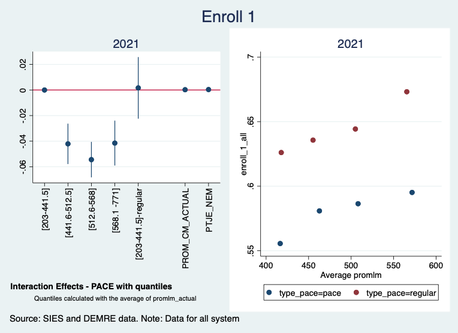

**Figure 1**. Modelo 1 que incluye todos los regresores indicados

En la tabla 1 se puede ver que si se excluye el puntaje de las pruebas y nem de los estudiantes **los resultados no cambian** de manera importante (solo la exclusión de puntaje en pruebas de admisión hace más negativa la diferencia). En definitiva no podemos rechazar $H_2$ pero si $H_1$.

Sumada a las hipótesis relativas a las características de los programas ($H_1$ y $H_2$), tenemos hipotesis relativas a características del estudiante ($H_3$ y $H_4$). Ambos modelos de interés están expresados en la **Figura 2**, donde *m1* incluye las $H_{1,2}$ y *m5* incluye $H_{3,4}$. Como se puede ver en la **Figura 2** tanto la dificultad de las carreras como la preferencia de los estudiantes parece ser un predictor importante a la hora de entender el dropout de los estudiantes en las carreras.

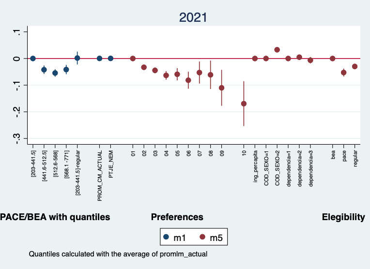

**Figure 2**. Modelo 1 y 2 (con todos los covariates)

Respecto a $H_3$ podemos decir que se puede rechazar la hipótesis nula con un 95%. Esto significa que estadísticamente podemos evidenciar que los estudiantes que quedan seleccionados en carreras en preferencias menos preferidas tienen más dropout que aquellos que quedan en sus carreras más preferidas, controlando por características del estudiante como su ingreso per capita, sexo, tipo de establecimiento y por la cuota que fueron seleccionados.

De manera muy interesante $H_4$ muestra que los estudiantes seleccionados por vía PACE y regular tienen un mayor dropout, respecto de los BEA. Ahora bien esta diferencia es más grande para estudiantes PACE.

Otro aspecto que no habíamos discutido es el efecto del género en el dropout. Como podemos ver, las mujeres tienen más probabilidades de mantenerse en la misma carrera que los hombres, controlando por todos los covariates del modelo rojo. Probablemente aquí haya un aspecto de estudio de interés (que profundizo en el apartado *Questions*)

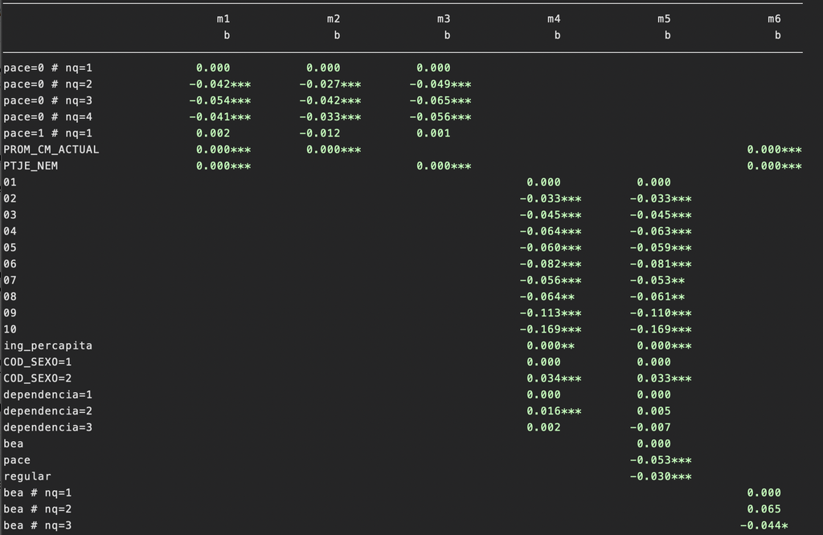

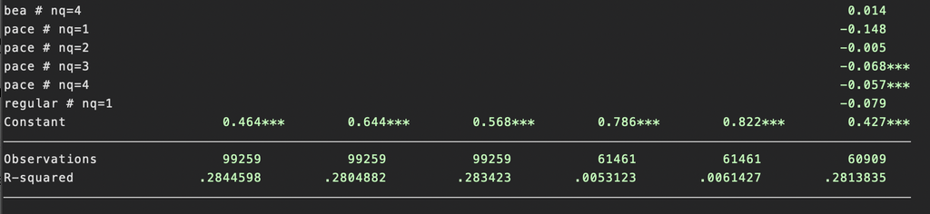

**Table 1**. Modelos de regresión

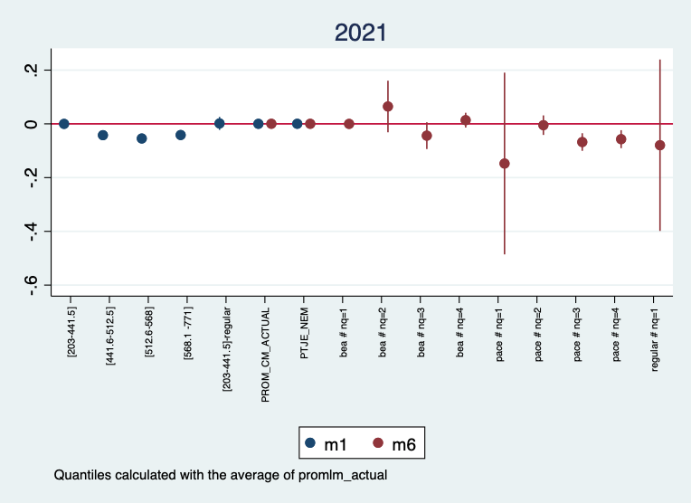

**Figure 3**. Comparando modelos con elegibilidad y selección de cuotas

# 4 Questions

Analysis of program dropping and switching need to look the patterns of academic and non-academic dimensions. Also we need to decompose the individual from the university-program effect.

- **¿Dropout: preferences, opportunities or abilities?**
  1. Students with similar abilities, but in different preference position.
  - Appears in the admission process again ¿persistence in preference portafolio?
  - Results: success or failure
  2. Students with similar preferences, but different abilities
  - Difference in academic outcomes such as GPA, graduation, academic progress
  3. Students with similar abilities and preferences, but different opportunities (Eckstein and Wolpin, 1999)
  - Labor market opportunities
  - Leave the University to work
  - Lower (wage) expectations about rewards from graduation and advantage at jobs that are done by non-graduates
  - Uncertain: dropout risk (Hendricks and Leukhina, 2018)
- **¿Dropout: school selection?**
1. Academic mismatch students and programs
2. Non-academic mismatch between students and university (experience, norms)

**Others ideas**

- **“‘They look like me’: switching decisions among undergraduates students”**
  - PACE/BEA to programs where there are more PACE/BEA students
  - Females to programs that are heavy-female
  - Control by preferences an ability (students do not improve student’s GPA)
  - Idea based on Bank and Slavings (1987) about self-referent identity labels and norms. They study retention and *reenrollment* behaviors

# 5 About graphs

El análisis se basa en

1. Binscatter (gráfico de la derecha): corresponde a la relación bivariada entre el cuantil de desempeño académico en que el está la carrera, y la probabilidad de enroll/switch según la forma de ingreso del estudiante
2. Coefplots (gráfico de la izquierda)[^2]: presenta los coeficientes estimados de un modelo con efecto fijo de carrera. En particular, la variable de interés en la interacción entre ser **elegible** a alguna **politica afirmativa** y el cuantil de de desempeño académico en la carrera que se matriculó por primera vez. Es decir, los coeficientes muestran la diferencia promedio en la probabilidad de estar retenido entre los elegibles PACE y regulares para cada uno de los cuantiles de performance académica de la carrera, controlando por el desempeño del estudiante y el efecto fijo de carrera. De manera simple, esto muestra el resultado académico en el primer año para un estudiante PACE y regular, según si la carrera es “más o menos competitiva/difícil” (según lo que se considere que mide el puntaje promedio ponderado).

Las figuras presentadas son una selección. En la carpeta `04_analysis/figures/combine` podrán encontrar el resto de las figuras. A su vez, la estimación completa de los modelos está en `04_analysis/models`

[^3]: Nota importante: notar coeficiente que está desordenado con un valor de quantil más bajo y aparece su efecto hacia otra dirección. Por problemas con el *reghdfe* se pone como categoría de referencia el 1 solo para una interacción.